# Analyses for ‘Seasonal variation of micro and macro soil invertebrate communities in a temperate forest’

2024-March-10

# Across Year Effects

## How does the seasonal variability impact different invertebrate communities?

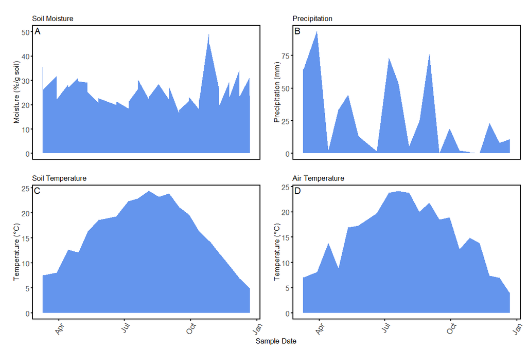

Climate Variables

## Nematodes:

### Total Nematodes

Significant drivers were season and the interaction between topography and tree functional type.

```r
model.total <-lme(total.nematodes~season+landscape.position+mycorrhizal.fungi.type+season:landscape.position+
                     mycorrhizal.fungi.type:landscape.position+season:mycorrhizal.fungi.type+
                     season:landscape.position:mycorrhizal.fungi.type,
                     random=list(sample.id=~1, tree.identity=~1), data = nematode)
summary(model.total)$tTable
```

```
                                                                         Value Std.Error  DF t-value p-value
(Intercept)                                                             4752.9      3136 100  1.5156  0.1328
seasonSpring                                                             403.3      3489 100  0.1156  0.9082
seasonSummer                                                            5744.1      3748 100  1.5327  0.1285
seasonFall                                                              8627.2      5464  29  1.5790  0.1252
seasonWinter.early                                                     13463.7      4455  29  3.0224  0.0052
landscape.positionUphill                                               10449.8      4945  29  2.1134  0.0433
mycorrhizal.fungi.typeECM                                               5091.7      6213  29  0.8195  0.4192
seasonSpring:landscape.positionUphill                                  -5268.3      5450 100 -0.9667  0.3360
seasonSummer:landscape.positionUphill                                  -2879.1      5833 100 -0.4936  0.6227
seasonFall:landscape.positionUphill                                      683.2      7602  29  0.0899  0.9290
seasonWinter.early:landscape.positionUphill                              -85.9      6668  29 -0.0129  0.9898
landscape.positionUphill:mycorrhizal.fungi.typeECM                     -9308.2      8237  29 -1.1301  0.2677
seasonSpring:mycorrhizal.fungi.typeECM                                 -2131.9      6696 100 -0.3184  0.7508
seasonSummer:mycorrhizal.fungi.typeECM                                 -3373.5      7089 100 -0.4759  0.6352
seasonFall:mycorrhizal.fungi.typeECM                                   -4380.6      8102  29 -0.5407  0.5929
seasonWinter.early:mycorrhizal.fungi.typeECM                          -10537.9      7656  29 -1.3764  0.1792
seasonSpring:landscape.positionUphill:mycorrhizal.fungi.typeECM         4143.7      8980 100  0.4614  0.6455
seasonSummer:landscape.positionUphill:mycorrhizal.fungi.typeECM         6900.9      9506 100  0.7260  0.4696
seasonFall:landscape.positionUphill:mycorrhizal.fungi.typeECM          -2226.4     10911  29 -0.2041  0.8397
seasonWinter.early:landscape.positionUphill:mycorrhizal.fungi.typeECM   1985.3     10386  29  0.1911  0.8497
```

```r
anova(model.total)
```

```
                                                 numDF denDF F-value p-value
(Intercept)                                          1    92     371  <.0001
season                                               4    92       9  <.0001
landscape.position                                   1    37      15  0.0004
mycorrhizal.fungi.type                               1    37       3  0.0811
season:landscape.position                            4    92       1  0.7350
landscape.position:mycorrhizal.fungi.type            1    37       4  0.0468
season:mycorrhizal.fungi.type                        4    92       2  0.1226
season:landscape.position:mycorrhizal.fungi.type     4    92       0  0.8527
```

```r
AIC(model.total)
```

```
[1] 2856
```

```r
rsquared(model.total)
```

```
         Response   family     link method Marginal Conditional
1 total.nematodes gaussian identity   none    0.381       0.492
```

```
 contrast                   estimate   SE df t.ratio p.value
 Downhill AM - Uphill AM       -8940 2140 29  -4.190  0.0010
 Downhill AM - Downhill ECM    -1007 2280 29  -0.440  0.9710
 Downhill AM - Uphill ECM      -2799 2100 29  -1.340  0.5490
 Uphill AM - Downhill ECM       7933 2310 29   3.430  0.0090
 Uphill AM - Uphill ECM         6141 2120 29   2.890  0.0340
 Downhill ECM - Uphill ECM     -1792 2270 29  -0.790  0.8590

Results are averaged over the levels of: season
Degrees-of-freedom method: containment
P value adjustment: tukey method for comparing a family of 4 estimates
```

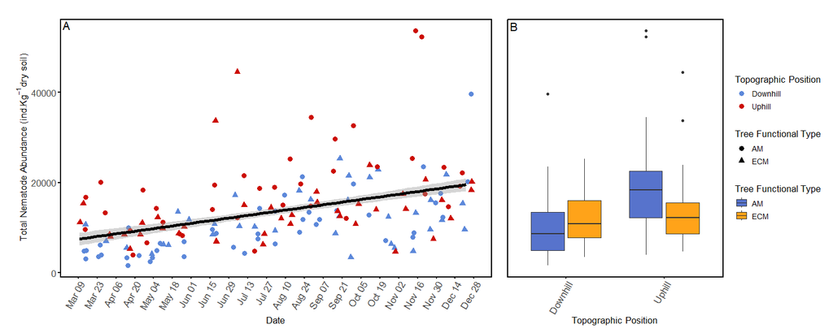

Total Nematode Abundance Time Series

```r
pairs(emmeans(model.total, specs= ~landscape.position*mycorrhizal.fungi.type))
```

### Bacterial Feeding Nematodes

Bacterial feeder abundance was best explained by season.

```r
model.bf <-lme(bacterial.feeders~season+landscape.position+season:landscape.position+
                 season:mycorrhizal.fungi.type+season:landscape.position:mycorrhizal.fungi.type,
               random=list(sample.id=~1, tree.identity=~1), data = nematode)
summary(model.bf)$tTable
```

```
                                                                        Value Std.Error DF t-value p-value
(Intercept)                                                            2128.2      1590 98  1.3383   0.184
seasonSpring                                                            668.1      1754 98  0.3809   0.704
seasonSummer                                                           2490.2      1901 98  1.3101   0.193
seasonFall                                                             2289.9      2788 31  0.8214   0.418
seasonWinter.early                                                     3546.2      2269 31  1.5626   0.128
landscape.positionUphill                                               2105.8      2506 31  0.8402   0.407
seasonSpring:landscape.positionUphill                                 -2114.0      2741 98 -0.7712   0.442
seasonSummer:landscape.positionUphill                                 -1093.8      2957 98 -0.3700   0.712
seasonFall:landscape.positionUphill                                     758.8      3871 31  0.1960   0.846
seasonWinter.early:landscape.positionUphill                           -3053.8      3395 31 -0.8996   0.375
seasonWinter.late:mycorrhizal.fungi.typeECM                            1979.2      3147 98  0.6289   0.531
seasonSpring:mycorrhizal.fungi.typeECM                                  748.1      2025 98  0.3694   0.713
seasonSummer:mycorrhizal.fungi.typeECM                                   63.3      1844 98  0.0343   0.973
seasonFall:mycorrhizal.fungi.typeECM                                   -404.5      2661 31 -0.1520   0.880
seasonWinter.early:mycorrhizal.fungi.typeECM                          -2564.0      2290 31 -1.1199   0.271
seasonWinter.late:landscape.positionUphill:mycorrhizal.fungi.typeECM  -2340.7      4173 98 -0.5609   0.576
seasonSpring:landscape.positionUphill:mycorrhizal.fungi.typeECM       -1232.8      2802 98 -0.4400   0.661
seasonSummer:landscape.positionUphill:mycorrhizal.fungi.typeECM        2209.2      2547 98  0.8673   0.388
seasonFall:landscape.positionUphill:mycorrhizal.fungi.typeECM         -2955.5      3656 31 -0.8084   0.425
seasonWinter.early:landscape.positionUphill:mycorrhizal.fungi.typeECM  2146.4      3238 31  0.6629   0.512
```

```r
anova(model.bf)
```

```
                                                 numDF denDF F-value p-value
(Intercept)                                          1    90   147.6  <.0001
season                                               4    90     3.0  0.0232
landscape.position                                   1    39     1.7  0.2016
season:landscape.position                            4    90     0.7  0.5631
season:mycorrhizal.fungi.type                        5    90     0.6  0.6969
season:landscape.position:mycorrhizal.fungi.type     5    90     0.5  0.7868
```

```r
AIC(model.bf)
```

```
[1] 2670
```

```r
rsquared(model.bf)
```

```
           Response   family     link method Marginal Conditional
1 bacterial.feeders gaussian identity   none    0.148       0.312
```

```r
pairs(emmeans(model.bf, specs= ~season))
```

```
NOTE: A nesting structure was detected in the fitted model:
    mycorrhizal.fungi.type %in% season
```

```
NOTE: Results may be misleading due to involvement in interactions
```

```
 contrast                   estimate   SE df t.ratio p.value
 Winter.late - Spring            727 1130 98   0.640  0.9670
 Winter.late - Summer          -2123 1200 98  -1.760  0.4010
 Winter.late - Fall            -1324 1390 31  -0.950  0.8730
 Winter.late - Winter.early     -869 1320 31  -0.660  0.9640
 Spring - Summer               -2850  866 98  -3.290  0.0120
 Spring - Fall                 -2051 1150 31  -1.780  0.4020
 Spring - Winter.early         -1597 1070 31  -1.490  0.5750
 Summer - Fall                   799 1110 31   0.720  0.9510
 Summer - Winter.early          1253 1030 31   1.220  0.7420
 Fall - Winter.early             454 1220 31   0.370  0.9960

Results are averaged over the levels of: landscape.position, mycorrhizal.fungi.type
Degrees-of-freedom method: containment
P value adjustment: tukey method for comparing a family of 5 estimates
```

### Fungal Feeding Nematodes

Fungal feeder abundance was best explained by season.

```r
model.ff <-lme(fungal.feeders~season+landscape.position+ season:landscape.position+mycorrhizal.fungi.type:landscape.position+
                 +season:landscape.position:mycorrhizal.fungi.type,
               random=list(sample.id=~1, tree.identity=~1), data = nematode)
summary(model.ff)$tTable
```

```
                                                                           Value Std.Error  DF  t-value p-value
(Intercept)                                                               74.243       176 100  0.42086   0.675
seasonSpring                                                               0.156       176 100  0.00089   0.999
seasonSummer                                                              47.931       209 100  0.22927   0.819
seasonFall                                                               208.031       332  29  0.62594   0.536
seasonWinter.early                                                       112.956       266  29  0.42455   0.674
landscape.positionUphill                                                  79.329       277  29  0.28675   0.776
seasonSpring:landscape.positionUphill                                   -195.584       276 100 -0.70935   0.480
seasonSummer:landscape.positionUphill                                    -43.881       323 100 -0.13596   0.892
seasonFall:landscape.positionUphill                                      570.657       451  29  1.26398   0.216
seasonWinter.early:landscape.positionUphill                             -199.457       395  29 -0.50520   0.617
landscape.positionDownhill:mycorrhizal.fungi.typeECM                     340.494       343  29  0.99171   0.330
landscape.positionUphill:mycorrhizal.fungi.typeECM                      -146.584       301  29 -0.48642   0.630
seasonSpring:landscape.positionDownhill:mycorrhizal.fungi.typeECM       -224.593       342 100 -0.65584   0.513
seasonSummer:landscape.positionDownhill:mycorrhizal.fungi.typeECM       -217.399       386 100 -0.56270   0.575
seasonFall:landscape.positionDownhill:mycorrhizal.fungi.typeECM          -47.806       474  29 -0.10088   0.920
seasonWinter.early:landscape.positionDownhill:mycorrhizal.fungi.typeECM -245.604       444  29 -0.55304   0.584
seasonSpring:landscape.positionUphill:mycorrhizal.fungi.typeECM          197.016       306 100  0.64323   0.522
seasonSummer:landscape.positionUphill:mycorrhizal.fungi.typeECM            6.206       350 100  0.01776   0.986
seasonFall:landscape.positionUphill:mycorrhizal.fungi.typeECM           -384.889       425  29 -0.90594   0.372
seasonWinter.early:landscape.positionUphill:mycorrhizal.fungi.typeECM    324.051       412  29  0.78559   0.438
```

```r
anova(model.ff)
```

```
                                                 numDF denDF F-value p-value
(Intercept)                                          1    92   21.30  <.0001
season                                               4    92    4.28  0.0032
landscape.position                                   1    37    0.28  0.6008
season:landscape.position                            4    92    0.31  0.8731
landscape.position:mycorrhizal.fungi.type            2    37    1.08  0.3497
season:landscape.position:mycorrhizal.fungi.type     8    92    0.56  0.8041
```

```r
AIC(model.ff)
```

```
[1] 2056
```

```r
rsquared(model.ff)
```

```
        Response   family     link method Marginal Conditional
1 fungal.feeders gaussian identity   none    0.213       0.479
```

```r
pairs(emmeans(model.ff, specs= ~season))
```

```
NOTE: A nesting structure was detected in the fitted model:
    mycorrhizal.fungi.type %in% landscape.position
```

```
NOTE: Results may be misleading due to involvement in interactions
```

```
 contrast                   estimate    SE  df t.ratio p.value
 Winter.late - Spring            105 115.0 100   0.910  0.8920
 Winter.late - Summer             27 130.0 100   0.210  1.0000
 Winter.late - Fall             -385 159.0  29  -2.420  0.1380
 Winter.late - Winter.early      -33 152.0  29  -0.220  0.9990
 Spring - Summer                 -78  91.5 100  -0.850  0.9140
 Spring - Fall                  -490 136.0  29  -3.610  0.0090
 Spring - Winter.early          -137 127.0  29  -1.080  0.8140
 Summer - Fall                  -412 134.0  29  -3.080  0.0330
 Summer - Winter.early           -60 124.0  29  -0.480  0.9890
 Fall - Winter.early             352 149.0  29   2.370  0.1540

Results are averaged over the levels of: mycorrhizal.fungi.type, landscape.position
Degrees-of-freedom method: containment
P value adjustment: tukey method for comparing a family of 5 estimates
```

### Plant Parasitic Nematodes

Best explained by season and the interaction between topography and tree functional type.

```r
model.pp <-lme(plant.parasites.aph.~season+landscape.position+mycorrhizal.fungi.type + season:landscape.position+mycorrhizal.fungi.type:landscape.position+
                  season:mycorrhizal.fungi.type+season:landscape.position:mycorrhizal.fungi.type,
                random=list(sample.id=~1, tree.identity=~1), data = nematode)
summary(model.pp)$tTable
```

```
                                                                      Value Std.Error  DF t-value p-value
(Intercept)                                                            2143      2322 100  0.9228  0.3583
seasonSpring                                                           -174      2614 100 -0.0665  0.9471
seasonSummer                                                           2831      2774 100  1.0207  0.3098
seasonFall                                                             5535      4010  29  1.3802  0.1781
seasonWinter.early                                                     8656      3277  29  2.6417  0.0132
landscape.positionUphill                                               7295      3663  29  1.9918  0.0559
mycorrhizal.fungi.typeECM                                              2318      4607  29  0.5031  0.6187
seasonSpring:landscape.positionUphill                                 -2363      4082 100 -0.5790  0.5639
seasonSummer:landscape.positionUphill                                 -1480      4320 100 -0.3426  0.7326
seasonFall:landscape.positionUphill                                    -606      5597  29 -0.1084  0.9145
seasonWinter.early:landscape.positionUphill                            3052      4910  29  0.6215  0.5391
landscape.positionUphill:mycorrhizal.fungi.typeECM                    -5553      6106  29 -0.9094  0.3706
seasonSpring:mycorrhizal.fungi.typeECM                                 -358      5008 100 -0.0714  0.9432
seasonSummer:mycorrhizal.fungi.typeECM                                 -632      5259 100 -0.1203  0.9045
seasonFall:mycorrhizal.fungi.typeECM                                  -1480      5973  29 -0.2478  0.8060
seasonWinter.early:mycorrhizal.fungi.typeECM                          -5279      5650  29 -0.9343  0.3578
seasonSpring:landscape.positionUphill:mycorrhizal.fungi.typeECM        1735      6716 100  0.2584  0.7967
seasonSummer:landscape.positionUphill:mycorrhizal.fungi.typeECM        1166      7048 100  0.1655  0.8689
seasonFall:landscape.positionUphill:mycorrhizal.fungi.typeECM         -2129      8047  29 -0.2645  0.7932
seasonWinter.early:landscape.positionUphill:mycorrhizal.fungi.typeECM -3191      7659  29 -0.4166  0.6800
```

```r
anova(model.pp)
```

```
                                                 numDF denDF F-value p-value
(Intercept)                                          1    92   231.6  <.0001
season                                               4    92     7.5  <.0001
landscape.position                                   1    37    14.8  0.0005
mycorrhizal.fungi.type                               1    37     4.7  0.0370
season:landscape.position                            4    92     0.5  0.7535
landscape.position:mycorrhizal.fungi.type            1    37     7.1  0.0115
season:mycorrhizal.fungi.type                        4    92     1.8  0.1413
season:landscape.position:mycorrhizal.fungi.type     4    92     0.2  0.9276
```

```r
pairs(emmeans(model.pp, specs= ~landscape.position*mycorrhizal.fungi.type))
```

```
 contrast                   estimate   SE df t.ratio p.value
 Downhill AM - Uphill AM       -7016 1560 29  -4.490  0.0010
 Downhill AM - Downhill ECM     -768 1670 29  -0.460  0.9670
 Downhill AM - Uphill ECM      -1747 1530 29  -1.140  0.6690
 Uphill AM - Downhill ECM       6247 1690 29   3.690  0.0050
 Uphill AM - Uphill ECM         5268 1560 29   3.390  0.0100
 Downhill ECM - Uphill ECM      -979 1670 29  -0.590  0.9350

Results are averaged over the levels of: season
Degrees-of-freedom method: containment
P value adjustment: tukey method for comparing a family of 4 estimates
```

```r
AIC(model.pp)
```

```
[1] 2777
```

```r
rsquared(model.pp)
```

```
              Response   family     link method Marginal Conditional
1 plant.parasites.aph. gaussian identity   none     0.38       0.481
```

```r
pairs(emmeans(model.pp, specs= ~season))
```

```
 contrast                   estimate   SE  df t.ratio p.value
 Winter.late - Spring           1100 1680 100   0.660  0.9650
 Winter.late - Summer          -2066 1760 100  -1.170  0.7670
 Winter.late - Fall            -3959 2010  29  -1.970  0.3060
 Winter.late - Winter.early    -6745 1920  29  -3.520  0.0120
 Spring - Summer               -3167 1280 100  -2.480  0.1030
 Spring - Fall                 -5060 1660  29  -3.050  0.0370
 Spring - Winter.early         -7845 1540  29  -5.090  <.0001
 Summer - Fall                 -1893 1600  29  -1.180  0.7610
 Summer - Winter.early         -4679 1480  29  -3.170  0.0270
 Fall - Winter.early           -2786 1750  29  -1.590  0.5130

Results are averaged over the levels of: landscape.position, mycorrhizal.fungi.type
Degrees-of-freedom method: containment
P value adjustment: tukey method for comparing a family of 5 estimates
```

### Omnivorous and Predatory Nematodes

A new group created with the sum of omnivorous and predatory nematodes. This group was best explained by season and topography.

```r
model.pred1 <-lme(om.pr~ season+landscape.position+ mycorrhizal.fungi.type + season:landscape.position + mycorrhizal.fungi.type:landscape.position + season:mycorrhizal.fungi.type + season:mycorrhizal.fungi.type:landscape.position,
                  random=list(sample.id=~1, tree.identity=~1), data = nematode)
summary(model.pred1)$tTable
```

```
                                                                       Value Std.Error  DF t-value p-value
(Intercept)                                                            175.8       204 100  0.8633  0.3900
seasonSpring                                                           -29.7       257 100 -0.1156  0.9082
seasonSummer                                                           359.4       239 100  1.5037  0.1358
seasonFall                                                             417.8       323  29  1.2942  0.2058
seasonWinter.early                                                     623.4       270  29  2.3097  0.0282
landscape.positionUphill                                               402.2       322  29  1.2492  0.2216
mycorrhizal.fungi.typeECM                                              186.6       407  29  0.4582  0.6502
seasonSpring:landscape.positionUphill                                 -155.5       398 100 -0.3903  0.6971
seasonSummer:landscape.positionUphill                                  260.8       374 100  0.6965  0.4877
seasonFall:landscape.positionUphill                                    -19.9       465  29 -0.0428  0.9662
seasonWinter.early:landscape.positionUphill                            386.5       408  29  0.9474  0.3513
landscape.positionUphill:mycorrhizal.fungi.typeECM                    -450.5       539  29 -0.8362  0.4099
seasonSpring:mycorrhizal.fungi.typeECM                                 -87.9       481 100 -0.1828  0.8553
seasonSummer:mycorrhizal.fungi.typeECM                                -277.2       461 100 -0.6010  0.5492
seasonFall:mycorrhizal.fungi.typeECM                                    81.7       501  29  0.1629  0.8717
seasonWinter.early:mycorrhizal.fungi.typeECM                          -230.9       478  29 -0.4829  0.6328
seasonSpring:landscape.positionUphill:mycorrhizal.fungi.typeECM        448.9       645 100  0.6955  0.4884
seasonSummer:landscape.positionUphill:mycorrhizal.fungi.typeECM        446.0       616 100  0.7246  0.4704
seasonFall:landscape.positionUphill:mycorrhizal.fungi.typeECM           48.2       679  29  0.0709  0.9440
seasonWinter.early:landscape.positionUphill:mycorrhizal.fungi.typeECM  -72.0       645  29 -0.1117  0.9118
```

```r
anova(model.pred1)
```

```
                                                 numDF denDF F-value p-value
(Intercept)                                          1    92     317  <.0001
season                                               4    92      12  <.0001
landscape.position                                   1    37      25  <.0001
mycorrhizal.fungi.type                               1    37       0   0.488
season:landscape.position                            4    92       2   0.141
landscape.position:mycorrhizal.fungi.type            1    37       2   0.189
season:mycorrhizal.fungi.type                        4    92       1   0.538
season:landscape.position:mycorrhizal.fungi.type     4    92       1   0.736
```

```r
AIC(model.pred1) #2145
```

```
[1] 2145
```

```r
AICc(model.pred1) #2153
```

```
[1] 2153
```

```r
rsquared(model.pred1) #37
```

```
  Response   family     link method Marginal Conditional
1    om.pr gaussian identity   none    0.365       0.368
```

```
NOTE: Results may be misleading due to involvement in interactions
```

```
 contrast                   estimate  SE  df t.ratio p.value
 Winter.late - Spring             39 161 100   0.240  0.9990
 Winter.late - Summer           -463 154 100  -3.010  0.0270
 Winter.late - Fall             -461 170  29  -2.710  0.0760
 Winter.late - Winter.early     -683 161  29  -4.240  0.0020
 Spring - Summer                -502 116 100  -4.320  <.0001
 Spring - Fall                  -500 137  29  -3.650  0.0080
 Spring - Winter.early          -722 126  29  -5.730  <.0001
 Summer - Fall                     2 127  29   0.010  1.0000
 Summer - Winter.early          -221 116  29  -1.910  0.3370
 Fall - Winter.early            -222 136  29  -1.630  0.4890

Results are averaged over the levels of: landscape.position, mycorrhizal.fungi.type
Degrees-of-freedom method: containment
P value adjustment: tukey method for comparing a family of 5 estimates
```

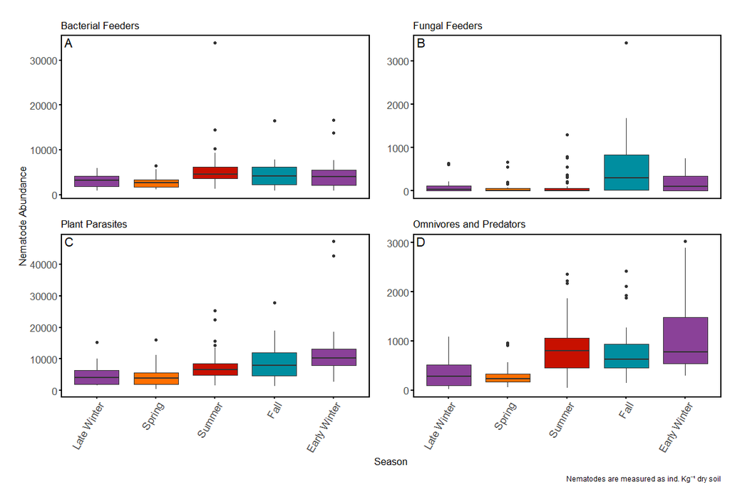

Nematode Trophic Groups by Season

```r
pairs(emmeans(model.pred1, specs= ~season))
```

### Nematode Diversity (Simpson Diversity Index)

Simpson diversity was best explained by tree functional type and season

```r
worm.simp1 <-lme(simpson~season+landscape.position+mycorrhizal.fungi.type +
                  season:landscape.position+mycorrhizal.fungi.type:landscape.position+
                  season:mycorrhizal.fungi.type+season:landscape.position:mycorrhizal.fungi.type,
                  random=list(sample.id=~1, tree.identity=~1), data = nematode)
summary(worm.simp1)$tTable
```

```
##                                                                          Value Std.Error  DF t-value  p-value
## (Intercept)                                                            0.51920    0.0386 100 13.4546 3.60e-24
## seasonSpring                                                          -0.01228    0.0482 100 -0.2547 7.99e-01
## seasonSummer                                                           0.00101    0.0454 100  0.0223 9.82e-01
## seasonFall                                                             0.00670    0.0616  29  0.1088 9.14e-01
## seasonWinter.early                                                    -0.09316    0.0514  29 -1.8119 8.04e-02
## landscape.positionUphill                                              -0.04870    0.0610  29 -0.7982 4.31e-01
## mycorrhizal.fungi.typeECM                                              0.05998    0.0772  29  0.7772 4.43e-01
## seasonSpring:landscape.positionUphill                                 -0.01960    0.0748 100 -0.2622 7.94e-01
## seasonSummer:landscape.positionUphill                                  0.04781    0.0711 100  0.6724 5.03e-01
## seasonFall:landscape.positionUphill                                    0.01313    0.0885  29  0.1483 8.83e-01
## seasonWinter.early:landscape.positionUphill                            0.03137    0.0777  29  0.4039 6.89e-01
## landscape.positionUphill:mycorrhizal.fungi.typeECM                    -0.05196    0.1021  29 -0.5089 6.15e-01
## seasonSpring:mycorrhizal.fungi.typeECM                                -0.01799    0.0904 100 -0.1989 8.43e-01
## seasonSummer:mycorrhizal.fungi.typeECM                                -0.05997    0.0875 100 -0.6852 4.95e-01
## seasonFall:mycorrhizal.fungi.typeECM                                  -0.05106    0.0954  29 -0.5353 5.97e-01
## seasonWinter.early:mycorrhizal.fungi.typeECM                          -0.01328    0.0907  29 -0.1465 8.85e-01
## seasonSpring:landscape.positionUphill:mycorrhizal.fungi.typeECM        0.06299    0.1214 100  0.5190 6.05e-01
## seasonSummer:landscape.positionUphill:mycorrhizal.fungi.typeECM        0.07877    0.1168 100  0.6742 5.02e-01
## seasonFall:landscape.positionUphill:mycorrhizal.fungi.typeECM          0.08175    0.1292  29  0.6329 5.32e-01
## seasonWinter.early:landscape.positionUphill:mycorrhizal.fungi.typeECM  0.09090    0.1225  29  0.7421 4.64e-01
```

```r
anova(worm.simp1)
```

```
##                                                  numDF denDF F-value p-value
## (Intercept)                                          1    92    4242  <.0001
## season                                               4    92       3  0.0106
## landscape.position                                   1    37       1  0.2702
## mycorrhizal.fungi.type                               1    37       5  0.0341
## season:landscape.position                            4    92       1  0.4118
## landscape.position:mycorrhizal.fungi.type            1    37       0  0.5689
## season:mycorrhizal.fungi.type                        4    92       0  0.8001
## season:landscape.position:mycorrhizal.fungi.type     4    92       0  0.9605
```

```r
AIC(worm.simp1)
```

```
## [1] -172
```

```r
rsquared(worm.simp1)
```

```
##   Response   family     link method Marginal Conditional
## 1  simpson gaussian identity   none    0.153       0.167
```

### Predator-Prey Index

No significant interactions, but best model contains season only.

```r
model.predator.prey.total <-lme(trophic.index~season,
                                random=list(sample.id=~1, tree.identity=~1), data = nematode)
summary(model.predator.prey.total)$tTable
```

```
##                      Value Std.Error  DF t-value p-value
## (Intercept)        0.04046    0.0145 106   2.783 0.00638
## seasonSpring       0.00594    0.0165 106   0.361 0.71885
## seasonSummer       0.02650    0.0170 106   1.559 0.12209
## seasonFall         0.04128    0.0190  38   2.170 0.03634
## seasonWinter.early 0.02611    0.0186  38   1.406 0.16785
```

```r
anova(model.predator.prey.total)
```

```
##             numDF denDF F-value p-value
## (Intercept)     1   104   143.8  <.0001
## season          4   104     1.8   0.138
```

```r
rsquared(model.predator.prey.total) #18
```

```
##        Response   family     link method Marginal Conditional
## 1 trophic.index gaussian identity   none   0.0549       0.178
```

```r
AIC(model.predator.prey.total) #-413
```

```
## [1] -413
```

```r
AICc(model.predator.prey.total) #-412
```

```
## [1] -412
```

```r
pairs(emmeans(model.predator.prey.total, "season"))
```

```
##  contrast                   estimate     SE  df t.ratio p.value
##  Winter.late - Spring        -0.0059 0.0165 106  -0.361  0.9960
##  Winter.late - Summer        -0.0265 0.0170 106  -1.559  0.5270
##  Winter.late - Fall          -0.0413 0.0190  38  -2.170  0.2130
##  Winter.late - Winter.early  -0.0261 0.0186  38  -1.406  0.6280
##  Spring - Summer             -0.0206 0.0130 106  -1.583  0.5120
##  Spring - Fall               -0.0353 0.0160  38  -2.206  0.1990
##  Spring - Winter.early       -0.0202 0.0155  38  -1.303  0.6910
##  Summer - Fall               -0.0148 0.0152  38  -0.970  0.8670
##  Summer - Winter.early        0.0004 0.0147  38   0.026  1.0000
##  Fall - Winter.early          0.0152 0.0169  38   0.900  0.8950
##
## Degrees-of-freedom method: containment
## P value adjustment: tukey method for comparing a family of 5 estimates
```

### Total Root Feeding to Free Living Nematodes

Best explained by season and the interaction between topography and tree functional type.

```r
model.lifestyle.total <-lme(lifestyle.index~season+landscape.position+ mycorrhizal.fungi.type +
                              season:landscape.position+mycorrhizal.fungi.type:landscape.position,
                            random=list(sample.id=~1, tree.identity=~1), na.action = na.omit, data = nematode)
summary(model.lifestyle.total)$tTable
```

```
##                                                      Value Std.Error  DF t-value p-value
## (Intercept)                                         1.0399     0.543 104   1.916  0.0582
## seasonSpring                                       -0.2316     0.657 104  -0.352  0.7252
## seasonSummer                                        0.1827     0.619 104   0.295  0.7684
## seasonFall                                          0.6564     0.686  33   0.957  0.3453
## seasonWinter.early                                  1.4364     0.662  33   2.170  0.0373
## landscape.positionUphill                            1.4238     0.782  33   1.821  0.0777
## mycorrhizal.fungi.typeECM                           0.0982     0.362  33   0.271  0.7878
## seasonSpring:landscape.positionUphill               0.5308     0.928 104   0.572  0.5687
## seasonSummer:landscape.positionUphill              -0.8423     0.875 104  -0.963  0.3378
## seasonFall:landscape.positionUphill                -0.6586     0.974  33  -0.676  0.5036
## seasonWinter.early:landscape.positionUphill        -0.4268     0.932  33  -0.458  0.6499
## landscape.positionUphill:mycorrhizal.fungi.typeECM -1.0502     0.502  33  -2.092  0.0442
```

```r
anova(model.lifestyle.total)
```

```
##                                           numDF denDF F-value p-value
## (Intercept)                                   1   100   211.7  <.0001
## season                                        4   100     4.9  0.0012
## landscape.position                            1    37     4.9  0.0335
## mycorrhizal.fungi.type                        1    37     2.8  0.1004
## season:landscape.position                     4   100     1.3  0.2887
## landscape.position:mycorrhizal.fungi.type     1    37     4.4  0.0434
```

```r
rsquared(model.lifestyle.total) #19
```

```
##          Response   family     link method Marginal Conditional
## 1 lifestyle.index gaussian identity   none    0.192       0.192
```

```r
AIC(model.lifestyle.total) #587
```

```
## [1] 587
```

```r
AICc(model.lifestyle.total) #591
```

```
## [1] 591
```

### Total Channel Ratio (Fungal Feeding : Bacterial Feeding Nematodes)

Best explained by season.

```r
model.channel.total <-lme(channel.index~season,
                          random=list(sample.id=~1, tree.identity=~1), na.action = na.omit, data = nematode)
summary(model.channel.total)$tTable
```

```
##                      Value Std.Error  DF t-value p-value
## (Intercept)         0.0397    0.0331 106   1.200 0.23273
## seasonSpring       -0.0211    0.0375 106  -0.562 0.57503
## seasonSummer       -0.0118    0.0387 106  -0.305 0.76112
## seasonFall          0.1508    0.0432  38   3.487 0.00125
## seasonWinter.early  0.0320    0.0422  38   0.759 0.45246
```

```r
anova(model.channel.total)
```

```
##             numDF denDF F-value p-value
## (Intercept)     1   104   30.61  <.0001
## season          4   104    6.78   1e-04
```

```r
rsquared(model.channel.total) #29
```

```
##        Response   family     link method Marginal Conditional
## 1 channel.index gaussian identity   none    0.189       0.292
```

```r
AIC(model.channel.total) #-166
```

```
## [1] -166
```

```r
AICc(model.channel.total) #-165
```

```
## [1] -165
```

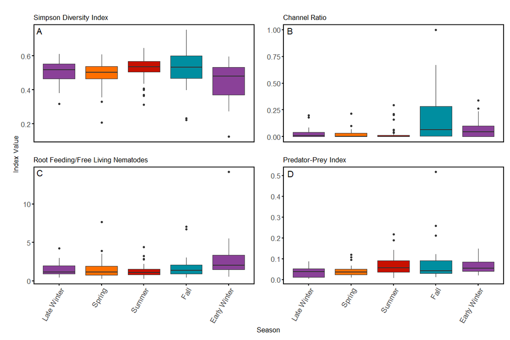

Nematode Indices by Season

### Supplemental Figure With other interactions

These are other significant interactions in the models that are highlighted in the results section.

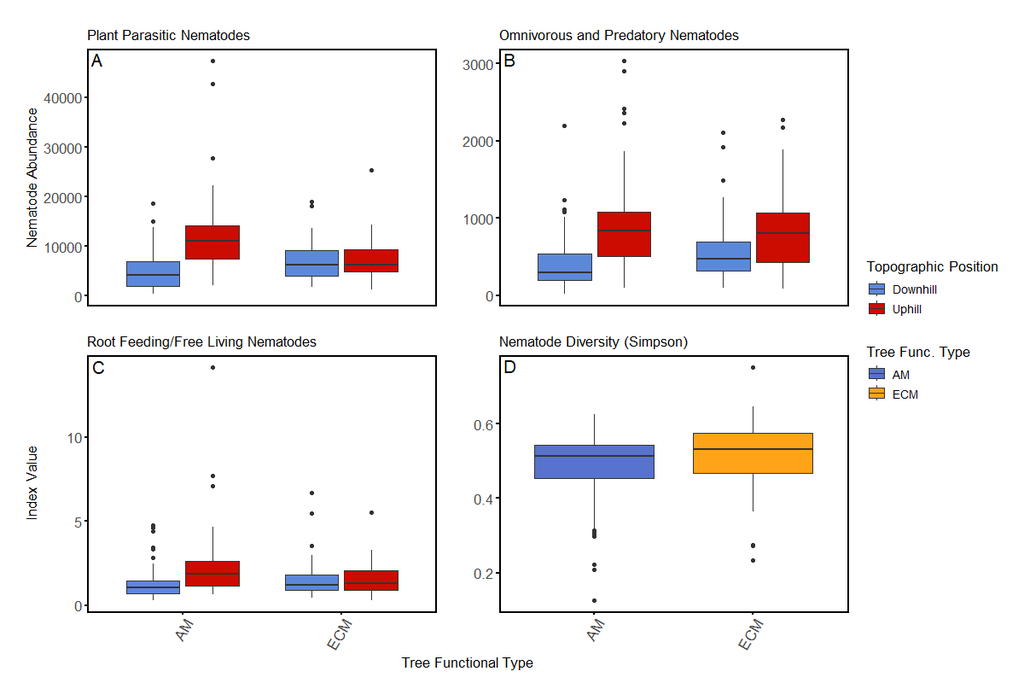

Other Signficant Interactions in Nematode Models

### Nematode Community Composition

The matrix used for this was using nematode relative abundance (calculated from Total Nematodes, so accounting for unknown nematodes in the overall community)

```r
#Running ANOVA of NMDS
adonis2(nematode_matrix.rel ~ season * landscape.position * mycorrhizal.fungi.type, data=nematode,
        permutations=999, by = "terms")
```

```
## Permutation test for adonis under reduced model
## Terms added sequentially (first to last)
## Permutation: free
## Number of permutations: 999
##
## adonis2(formula = nematode_matrix.rel ~ season * landscape.position * mycorrhizal.fungi.type, data = nematode, permutations = 999, by = "terms")
##                                                   Df SumOfSqs    R2     F Pr(>F)
## season                                             4     0.62 0.145  7.08  0.001 ***
## landscape.position                                 1     0.22 0.052 10.23  0.001 ***
## mycorrhizal.fungi.type                             1     0.02 0.005  0.88  0.356
## season:landscape.position                          4     0.27 0.062  3.03  0.018 *
## season:mycorrhizal.fungi.type                      4     0.03 0.008  0.39  0.902
## landscape.position:mycorrhizal.fungi.type          1     0.15 0.035  6.87  0.006 **
## season:landscape.position:mycorrhizal.fungi.type   4     0.02 0.004  0.22  0.988
## Residual                                         135     2.96 0.689
## Total                                            154     4.29 1.000
## ---
## Signif. codes:  0 '***' 0.001 '**' 0.01 '*' 0.05 '.' 0.1 ' ' 1
```

```r
# Season and landscape position signficant
# landscape position and mycorrhizal fungi
# season and landscape position alone

adonis2(nematode_matrix.rel ~ PRECIP + AIRTEMP + soil.moisture, data=nematode,
        permutations=999, by = "terms")
```

```
## Permutation test for adonis under reduced model
## Terms added sequentially (first to last)
## Permutation: free
## Number of permutations: 999
##
## adonis2(formula = nematode_matrix.rel ~ PRECIP + AIRTEMP + soil.moisture, data = nematode, permutations = 999, by = "terms")
##                Df SumOfSqs    R2    F Pr(>F)
## PRECIP          1     0.13 0.030 5.01  0.013 *
## AIRTEMP         1     0.18 0.042 6.85  0.004 **
## soil.moisture   1     0.05 0.011 1.75  0.180
## Residual      151     3.94 0.917
## Total         154     4.29 1.000
## ---
## Signif. codes:  0 '***' 0.001 '**' 0.01 '*' 0.05 '.' 0.1 ' ' 1
```

```r
# precipitation and air temp also drive community composition!
```

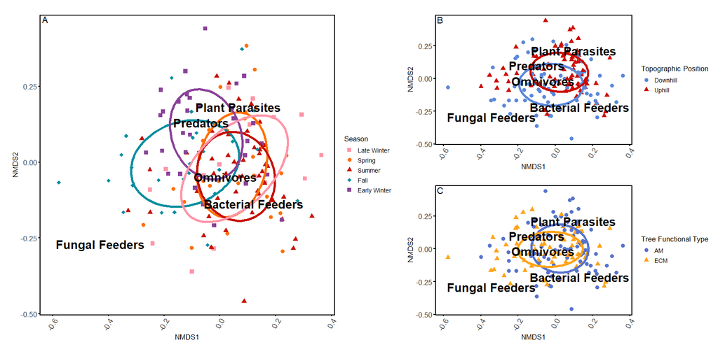

NMDS of Nematode Community Composition

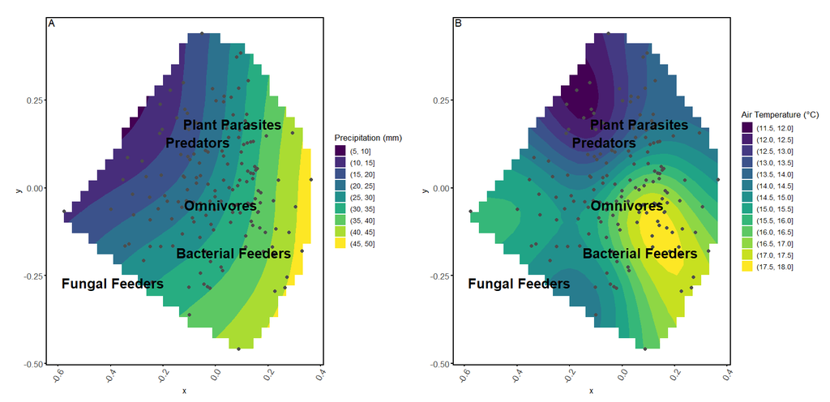

NMDS of Nematode Community Composition by Climate

## Macrofauna

Initial models included season, sample type (ecological group), landscape position (topography), and mycorhizal type (tree functional type) + all interactions

### Macrofauna Total Abundance

```r
# model with sample type
bug.total <-lme(sqrt(totalAbundance)~ season + sample.type + season:landscape.position +
                  mycorrhizal.fungi.type:landscape.position,
                random=list(tree.identity=~1, sample.id=~1), data = macrofauna)
summary(bug.total)
```

```
## Linear mixed-effects model fit by REML
##   Data: macrofauna
##   AIC BIC logLik
##   257 278   -113
##
## Random effects:
##  Formula: ~1 | tree.identity
##         (Intercept)
## StdDev:    0.000192
##
##  Formula: ~1 | sample.id %in% tree.identity
##         (Intercept) Residual
## StdDev:     0.00227       11
##
## Fixed effects:  sqrt(totalAbundance) ~ season + sample.type + season:landscape.position +      mycorrhizal.fungi.type:landscape.position
##                                                       Value Std.Error DF t-value p-value
## (Intercept)                                           12.85      6.27 16    2.05  0.0572
## seasonSpring                                          11.15      7.78  2    1.43  0.2882
## seasonSummer                                          16.48      7.78  2    2.12  0.1682
## seasonFall                                             5.97      7.78 16    0.77  0.4536
## seasonWinter.early                                     4.14      7.78 16    0.53  0.6017
## sample.typeSoil                                       23.47      3.48 16    6.75  0.0000
## seasonWinter.late:landscape.positionUphill            -4.98      8.61  2   -0.58  0.6211
## seasonSpring:landscape.positionUphill                -16.07      8.61  2   -1.87  0.2030
## seasonSummer:landscape.positionUphill                 -6.61      8.16  9   -0.81  0.4384
## seasonFall:landscape.positionUphill                   11.73      8.61 16    1.36  0.1917
## seasonWinter.early:landscape.positionUphill          -11.55      8.61 16   -1.34  0.1982
## landscape.positionDownhill:mycorrhizal.fungi.typeECM  -7.84      4.92  2   -1.59  0.2520
## landscape.positionUphill:mycorrhizal.fungi.typeECM    13.31      5.50  2    2.42  0.1366
##  Correlation:
##                                                      (Intr) ssnSpr ssnSmm ssnFll ssnWn. smpl.S ssnWntr.l:.U ssnSp:.U ssnSm:.U ssF:.U ssnWntr.r:.U l.D:..
## seasonSpring                                         -0.620
## seasonSummer                                         -0.620  0.500
## seasonFall                                           -0.620  0.500  0.500
## seasonWinter.early                                   -0.620  0.500  0.500  0.500
## sample.typeSoil                                      -0.277  0.000  0.000  0.000  0.000
## seasonWinter.late:landscape.positionUphill           -0.672  0.452  0.452  0.452  0.452  0.000
## seasonSpring:landscape.positionUphill                -0.112 -0.452  0.000  0.000  0.000  0.000  0.184
## seasonSummer:landscape.positionUphill                -0.118  0.000 -0.477  0.000  0.000  0.000  0.086        0.086
## seasonFall:landscape.positionUphill                  -0.112  0.000  0.000 -0.452  0.000  0.000  0.184        0.184    0.086
## seasonWinter.early:landscape.positionUphill          -0.112  0.000  0.000  0.000 -0.452  0.000  0.184        0.184    0.086    0.184
## landscape.positionDownhill:mycorrhizal.fungi.typeECM -0.392  0.000  0.000  0.000  0.000  0.000  0.286        0.286    0.302    0.286  0.286
## landscape.positionUphill:mycorrhizal.fungi.typeECM    0.000  0.000  0.000  0.000  0.000  0.000 -0.319       -0.319    0.000   -0.319 -0.319        0.000
##
## Standardized Within-Group Residuals:
##     Min      Q1     Med      Q3     Max
## -2.0483 -0.6084  0.0194  0.3546  2.1949
##
## Number of Observations: 40
## Number of Groups:
##                tree.identity sample.id %in% tree.identity
##                           11                           19
```

```r
anova(bug.total)
```

```
##                                           numDF denDF F-value p-value
## (Intercept)                                   1    11   299.3  <.0001
## season                                        4    11     2.8  0.0784
## sample.type                                   1    11    45.5  <.0001
## season:landscape.position                     5    11     1.9  0.1786
## landscape.position:mycorrhizal.fungi.type     2     6     4.2  0.0724
```

```r
rsquared(bug.total)
```

```
##         Response   family     link method Marginal Conditional
## 1 totalAbundance gaussian identity   none    0.657       0.657
```

```r
AIC(bug.total) #257
```

```
## [1] 257
```

```r
AICc(bug.total) #281
```

```
## [1] 281
```

```
## NOTE: A nesting structure was detected in the fitted model:
##     landscape.position %in% season, mycorrhizal.fungi.type %in% (season*landscape.position)
```

```
## NOTE: Results may be misleading due to involvement in interactions
```

```
##  contrast                   estimate  SE df t.ratio p.value
##  Winter.late - Spring          -5.60 5.5  2  -1.019  0.8340
##  Winter.late - Summer         -12.34 5.5  2  -2.244  0.4110
##  Winter.late - Fall           -14.33 5.5  2  -2.606  0.3340
##  Winter.late - Winter.early    -0.86 5.5  2  -0.156  1.0000
##  Spring - Summer               -6.73 5.5  2  -1.224  0.7520
##  Spring - Fall                 -8.73 5.5  2  -1.587  0.6110
##  Spring - Winter.early          4.75 5.5  2   0.863  0.8900
##  Summer - Fall                 -1.99 5.5  2  -0.362  0.9930
##  Summer - Winter.early         11.48 5.5  2   2.088  0.4510
##  Fall - Winter.early           13.48 5.5 16   2.450  0.1520
##
## Results are averaged over the levels of: sample.type, mycorrhizal.fungi.type, landscape.position
## Note: contrasts are still on the sqrt scale. Consider using
##       regrid() if you want contrasts of back-transformed estimates.
## Degrees-of-freedom method: containment
## P value adjustment: tukey method for comparing a family of 5 estimates
```

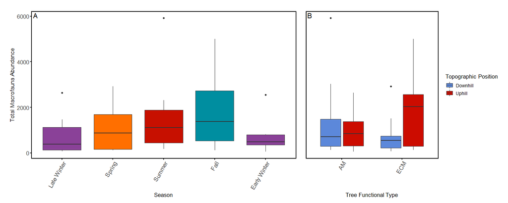

Total Macrofauna Abundance By Season

```r
pairs(emmeans(bug.total, specs= ~season))
```

### Macrofauna Shannon Diversity

Driven entirely by ecological group

```r
bug.shan <-lme(shannon~ sample.type,
               random=list(tree.identity=~1, sample.id=~1), data = macrofauna)
summary(bug.shan)
```

```
## Linear mixed-effects model fit by REML
##   Data: macrofauna
##    AIC  BIC logLik
##   41.9 50.1    -16
##
## Random effects:
##  Formula: ~1 | tree.identity
##         (Intercept)
## StdDev:       0.189
##
##  Formula: ~1 | sample.id %in% tree.identity
##         (Intercept) Residual
## StdDev:      0.0948    0.294
##
## Fixed effects:  shannon ~ sample.type
##                 Value Std.Error DF t-value p-value
## (Intercept)     1.311    0.0916 20   14.32  0.0000
## sample.typeSoil 0.325    0.0930 20    3.49  0.0023
##  Correlation:
##                 (Intr)
## sample.typeSoil -0.508
##
## Standardized Within-Group Residuals:
##     Min      Q1     Med      Q3     Max
## -2.9796 -0.4680  0.0439  0.5497  2.2599
##
## Number of Observations: 40
## Number of Groups:
##                tree.identity sample.id %in% tree.identity
##                           11                           19
```

```r
anova(bug.shan)
```

```
##             numDF denDF F-value p-value
## (Intercept)     1    20     349  <.0001
## sample.type     1    20      12  0.0023
```

```r
rsquared(bug.shan)
```

```
##   Response   family     link method Marginal Conditional
## 1  shannon gaussian identity   none    0.171       0.453
```

```r
AIC(bug.shan) #42
```

```
## [1] 41.9
```

```r
AICc(bug.shan) #44
```

```
## [1] 43.7
```

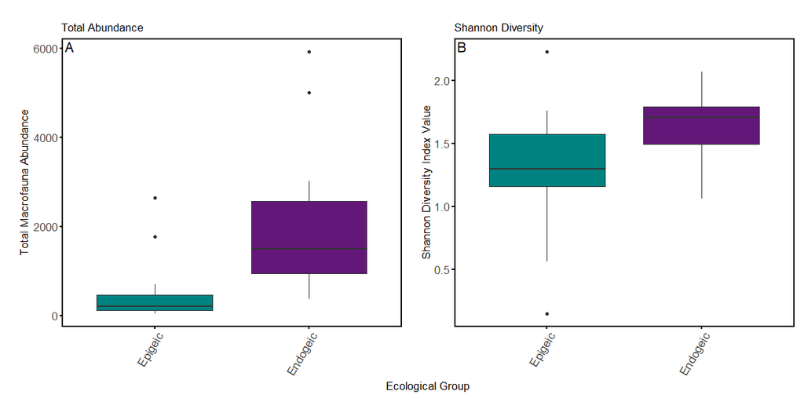

## Macrofauna By Sample Type

Models included season, topography, and tree functional type + all interactions

### Epigeic Abundance

No significant interactions in any model - this is the best using AIC

```r
litter.total <-lme(sqrt(totalAbundance)~ landscape.position + mycorrhizal.fungi.type +
                     mycorrhizal.fungi.type:landscape.position,
                   random=list(tree.identity=~1, sample.id=~1), data = macrofauna[macrofauna$sample.type == "Litter",])
summary(litter.total)
```

```
## Linear mixed-effects model fit by REML
##   Data: macrofauna[macrofauna$sample.type == "Litter", ]
##   AIC BIC logLik
##   144 149  -64.9
##
## Random effects:
##  Formula: ~1 | tree.identity
##         (Intercept)
## StdDev:        8.59
##
##  Formula: ~1 | sample.id %in% tree.identity
##         (Intercept) Residual
## StdDev:     0.00108     9.34
##
## Fixed effects:  sqrt(totalAbundance) ~ landscape.position + mycorrhizal.fungi.type +      mycorrhizal.fungi.type:landscape.position
##                                                    Value Std.Error DF t-value p-value
## (Intercept)                                        17.44      6.54  9   2.666  0.0258
## landscape.positionUphill                            5.18      8.10  6   0.639  0.5462
## mycorrhizal.fungi.typeECM                          -3.28      8.86  9  -0.370  0.7200
## landscape.positionUphill:mycorrhizal.fungi.typeECM -0.44     11.42  6  -0.038  0.9707
##  Correlation:
##                                                    (Intr) lnds.U m..ECM
## landscape.positionUphill                           -0.714
## mycorrhizal.fungi.typeECM                          -0.739  0.527
## landscape.positionUphill:mycorrhizal.fungi.typeECM  0.507 -0.709 -0.614
##
## Standardized Within-Group Residuals:
##    Min     Q1    Med     Q3    Max
## -1.219 -0.427 -0.146  0.187  2.081
##
## Number of Observations: 20
## Number of Groups:
##                tree.identity sample.id %in% tree.identity
##                           11                           19
```

```r
anova(litter.total)
```

```
##                                           numDF denDF F-value p-value
## (Intercept)                                   1     9   29.02  0.0004
## landscape.position                            1     6    0.93  0.3721
## mycorrhizal.fungi.type                        1     9    0.25  0.6303
## landscape.position:mycorrhizal.fungi.type     1     6    0.00  0.9707
```

```r
rsquared(litter.total)
```

```
##         Response   family     link method Marginal Conditional
## 1 totalAbundance gaussian identity   none   0.0619       0.492
```

```r
AIC(litter.total) #144
```

```
## [1] 144
```

```r
AICc(litter.total) #153
```

```
## [1] 153
```